# asthmaControlLevelAnalysis

# Preliminary Analysis

It is important to check whether the assumption of proportional odds (PO) is supported by the data. While it is not a perfectly legitimate statistical test, I compare the fitted fixed effects ordinal model with the baseline multinomial counterpart by performing a log-likehood ratio test (not legitimate because these models are not nested but it seems it is a well-accepted practice. See pages 289-304 of the textbook on applied logistic regressions by Hosmer and Lemeshow, 2002).

```r
formula1 <- as.formula("control_level ~ sex*age + age_sq + time_since_Dx + visit")
```

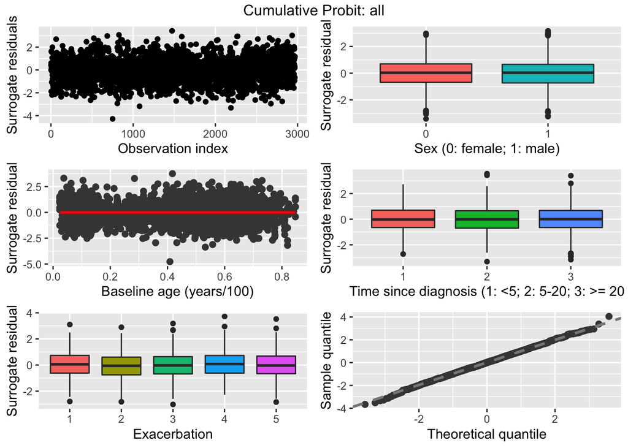

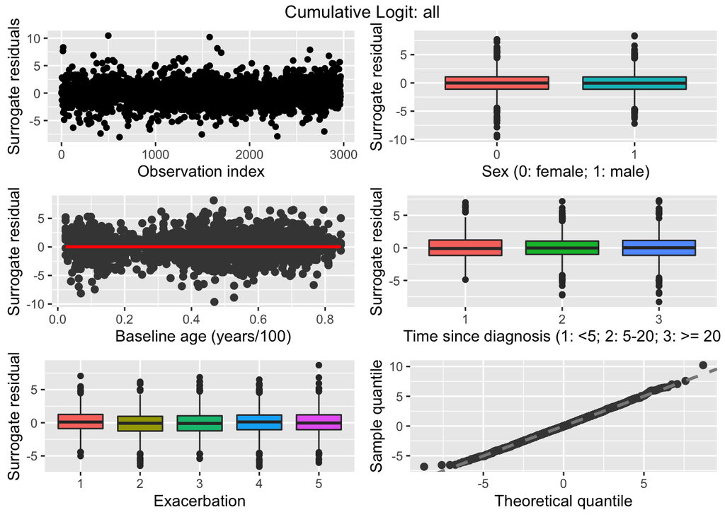

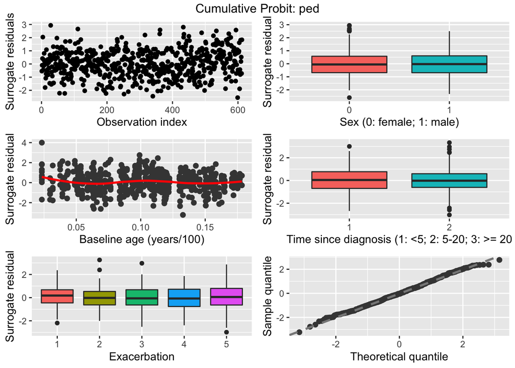

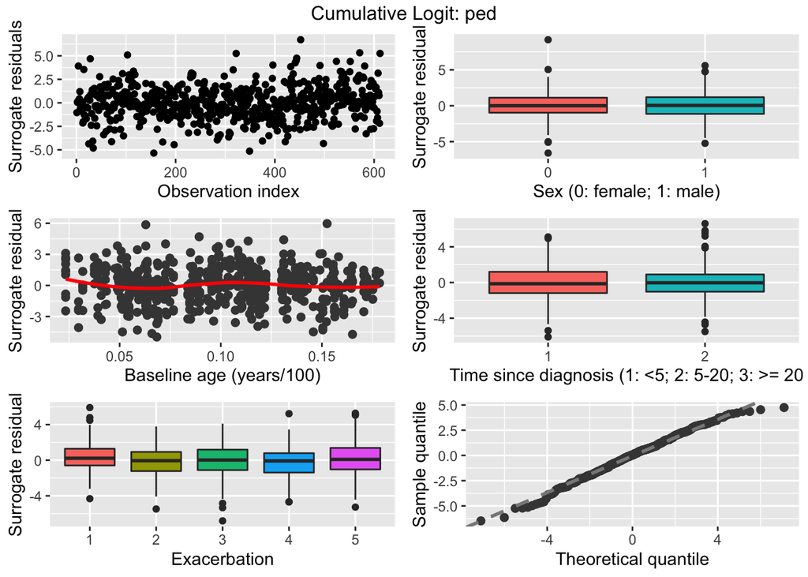

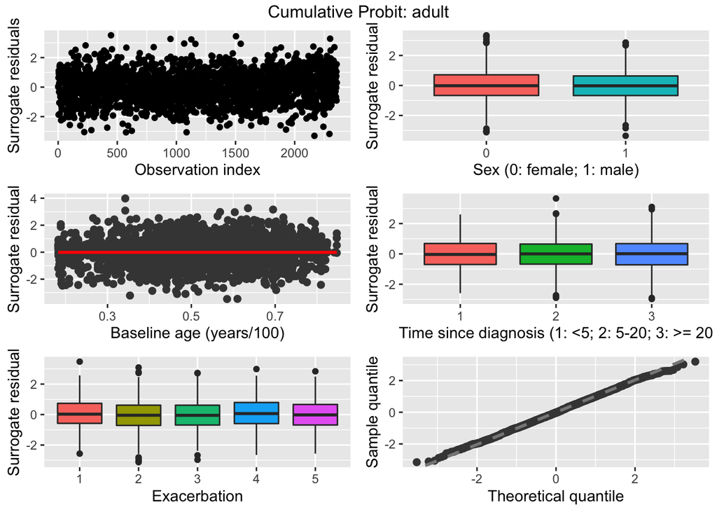

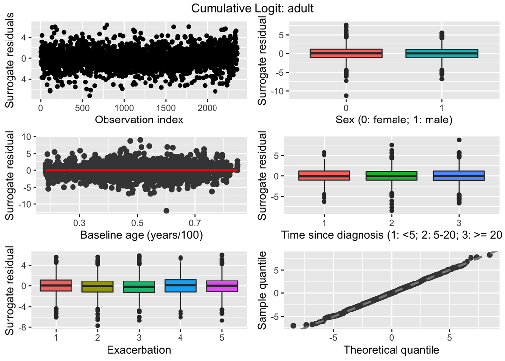

It appears the probit link seems to fit the data slightly better, as more data appear as outliers in the logit link models in the boxplots and more data deviate at the tails in the QQ plots. Overall, the model fits are adequate.

```
##              logit       probit
## all   1.569910e-02 2.926216e-02
## ped   5.299509e-02 7.182044e-02
## adult 1.202074e-05 9.629695e-06
```

# Random effects ordinal regression

Again I compare the two links, probit and logit. The AIC values are provided in the table below.

```
##          logit   probit
## all   5479.946 5490.306
## ped   1167.063 1167.401
## adult 4319.188 4328.982
```

The logit models are slightly better based on the AIC, so I report the fitted model estimates from the logit link.

### All

```
## Cumulative Link Mixed Model fitted with the adaptive Gauss-Hermite
## quadrature approximation with 5 quadrature points
##
## Call:
## clmm2(location = formula1, random = studyid, data = df_all, Hess = T,
##     link = "logistic", nAGQ = 5)
##
## Random effects:
##             Var  Std.Dev
## studyid 2.79123 1.670698
##
## Location coefficients:
##                Estimate Std. Error z value Pr(>|z|)
## sex1            0.4111   0.3634     1.1310 0.2580442
## age             3.6395   1.7142     2.1231 0.0337441
## age_sq         -3.9046   1.9048    -2.0499 0.0403717
## time_since_Dx2 -0.5931   0.2330    -2.5452 0.0109200
## time_since_Dx3 -0.0455   0.2493    -0.1826 0.8551086
## visit          -0.1368   0.0277    -4.9436 7.6709e-07
## sex1:age       -1.8910   0.7732    -2.4455 0.0144634
##
## No scale coefficients
##
## Threshold coefficients:
##     Estimate Std. Error z value
## 1|2 -1.1043   0.3766    -2.9319
## 2|3  2.0709   0.3785     5.4717
##
## log-likelihood: -2729.973
## AIC: 5479.946
## Condition number of Hessian: 18667.19
```

### Ped

```
## Cumulative Link Mixed Model fitted with the adaptive Gauss-Hermite
## quadrature approximation with 5 quadrature points
##
## Call:
## clmm2(location = formula1, random = studyid, data = df_ped, Hess = T,
##     link = "logistic", nAGQ = 5)
##
## Random effects:
##              Var  Std.Dev
## studyid 1.756185 1.325211
##
## Location coefficients:
##                Estimate Std. Error z value  Pr(>|z|)
## sex1             0.5762   0.8444     0.6824 0.49500849
## age            -18.8630  19.1325    -0.9859 0.32417387
## age_sq          93.6482  82.6433     1.1332 0.25714662
## time_since_Dx2  -0.4347   0.3743    -1.1612 0.24557112
## visit           -0.2289   0.0598    -3.8287 0.00012883
## sex1:age        -3.3957   7.4848    -0.4537 0.65005796
##
## No scale coefficients
##
## Threshold coefficients:
##     Estimate Std. Error z value
## 1|2  -2.2988   1.0820    -2.1246
## 2|3   0.5865   1.0777     0.5443
##
## log-likelihood: -574.5313
## AIC: 1167.063
## Condition number of Hessian: 5193440.74
```

### Adult

```
## Cumulative Link Mixed Model fitted with the adaptive Gauss-Hermite
## quadrature approximation with 5 quadrature points
##
## Call:
## clmm2(location = formula1, random = studyid, data = df_adult,
##     Hess = T, link = "logistic", nAGQ = 5)
##
## Random effects:
##              Var  Std.Dev
## studyid 3.102134 1.761287
##
## Location coefficients:
##                Estimate Std. Error z value Pr(>|z|)
## sex1            0.1528   0.6993     0.2185 0.82703214
## age             4.3732   3.7064     1.1799 0.23804221
## age_sq         -4.7933   3.5431    -1.3528 0.17610533
## time_since_Dx2 -0.5091   0.3250    -1.5664 0.11725045
## time_since_Dx3  0.0123   0.2992     0.0411 0.96725311
## visit          -0.1112   0.0313    -3.5559 0.00037664
## sex1:age       -1.4459   1.3205    -1.0950 0.27353110
##
## No scale coefficients
##
## Threshold coefficients:
##     Estimate Std. Error z value
## 1|2 -0.8936   1.0047    -0.8894
## 2|3  2.3684   1.0067     2.3528
##
## log-likelihood: -2149.594
## AIC: 4319.188
## Condition number of Hessian: 59220.86
```

I was not able to fit a random effects multinomial model for pediatric patients using available packages (mblogit) in R (always ran into convergence issues). I was able to fit it in SAS using GLIMMIX.

# Visual assessment of the PO assumption

I compute the estimated class probabilities for each patient, and then plot the probabilities against each categorical variable using color to stratify between the classes.

```r
pred <-function(eta, theta, cat = 1:(length(theta)+1), inv.link = plogis)
{
  Theta <- c(-1e3, theta, 1e3)
  sapply(cat, function(j)
    inv.link(Theta[j+1] - eta) - inv.link(Theta[j] - eta) )
}


prediction_generator <- function(model,formula,dat,inv.link=plogis){
  design_matrix <- model.matrix(formula,data=dat)[,-1] # remove intercept
  beta <- model$beta
  design_matrix <- design_matrix[,match(names(beta),colnames(design_matrix))]
  re <- data.frame(studyid=unique(dat$studyid),re=model$ranef)
  dat <- dat %>%
    left_join(re,by='studyid')
  lin <- (design_matrix %*% matrix(beta,nrow=length(beta))) + dat$re
  tmp <- pred(eta=lin,theta=model$Theta,inv.link=plogis)
  colnames(tmp) <- c("Controlled","Partially controlled","Uncontrolled")
  cbind(tmp,dat)
}
```

### All

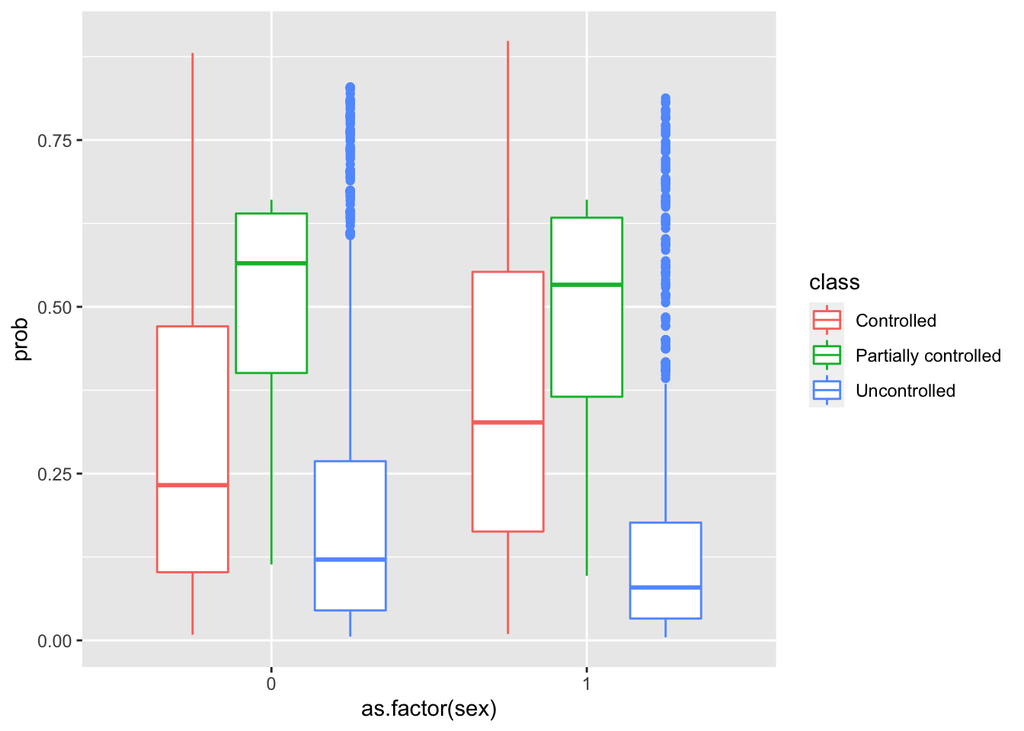

```r
tmp <- prediction_generator(lm.ordinal.logit,formula1,df_all) %>%
  gather("class","prob",1:3)

ggplot(data=tmp,aes(x=as.factor(sex),y=prob,colour=class))+
  geom_boxplot()
```

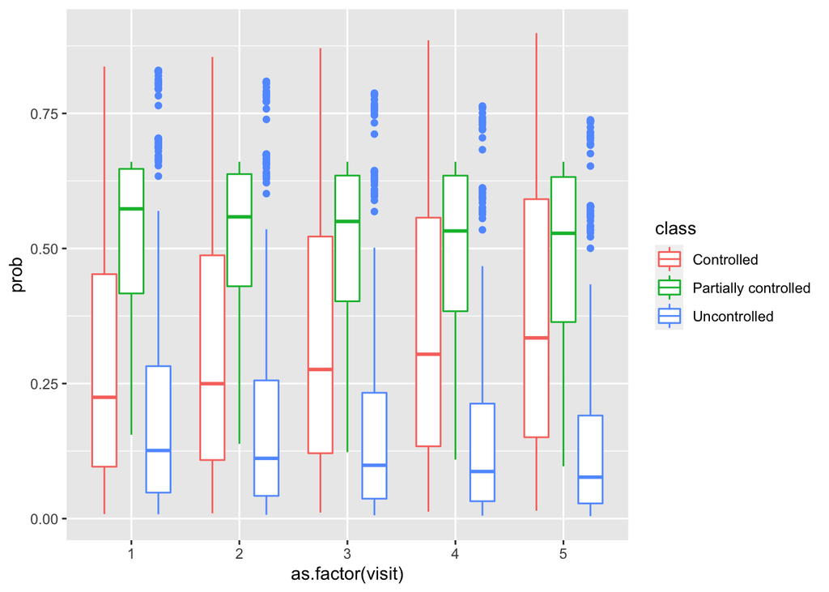

```r
ggplot(data=tmp,aes(x=as.factor(visit),y=prob,colour=class))+
  geom_boxplot()
```

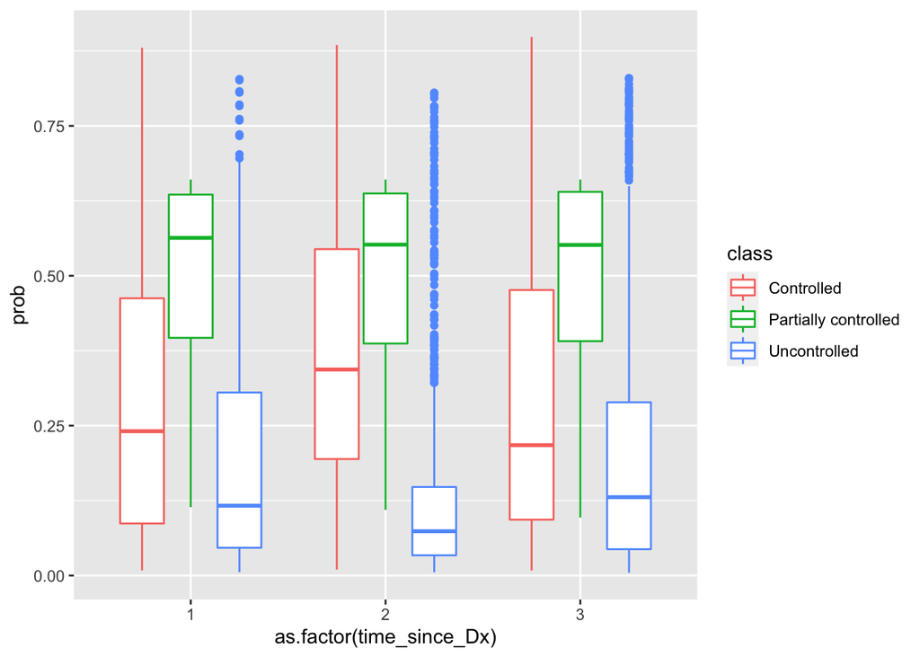

```r
ggplot(data=tmp,aes(x=as.factor(time_since_Dx),y=prob,colour=class))+
  geom_boxplot()
```

### Ped

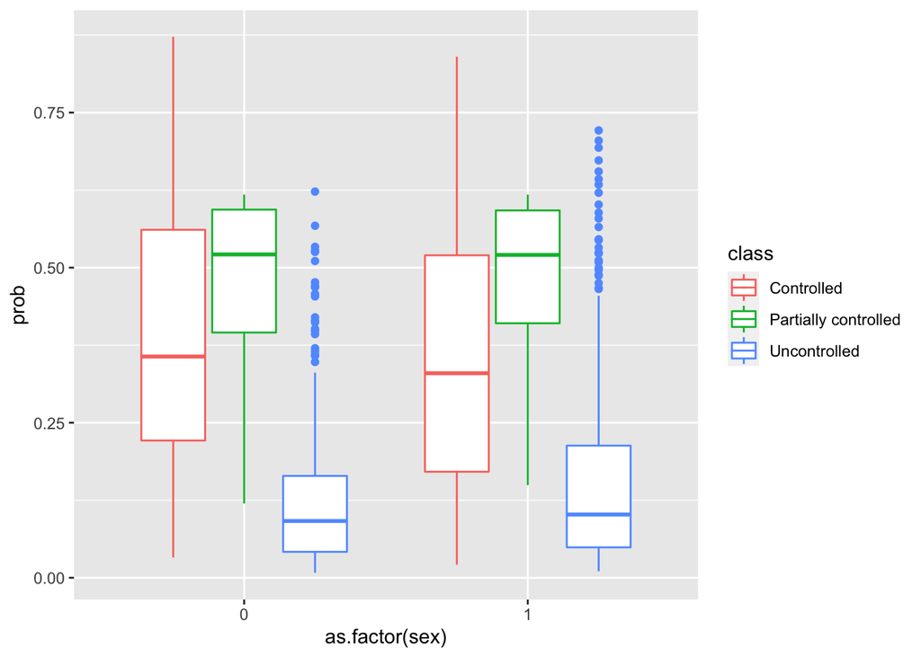

```r
tmp <- prediction_generator(lm.ordinal.ped.logit,formula1,df_ped) %>%
  gather("class","prob",1:3)

ggplot(data=tmp,aes(x=as.factor(sex),y=prob,colour=class))+
  geom_boxplot()
```

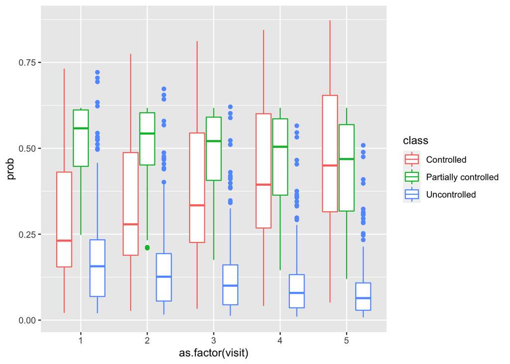

```r
ggplot(data=tmp,aes(x=as.factor(visit),y=prob,colour=class))+
  geom_boxplot()
```

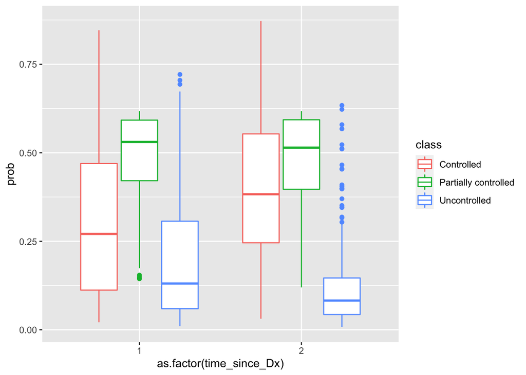

```r
ggplot(data=tmp,aes(x=as.factor(time_since_Dx),y=prob,colour=class))+
  geom_boxplot()
```

### Adult

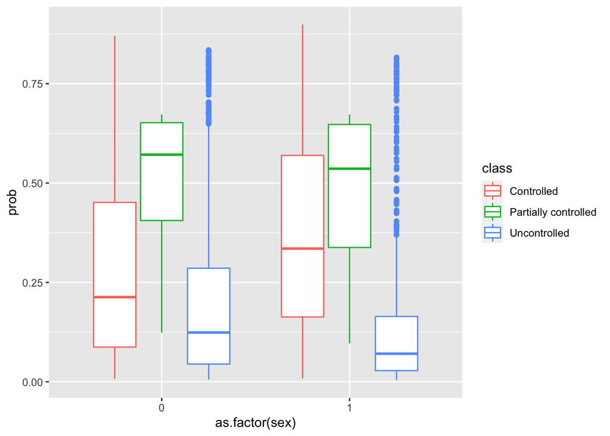

```r
tmp <- prediction_generator(lm.ordinal.adult.logit,formula1,df_adult) %>%
  gather("class","prob",1:3)

ggplot(data=tmp,aes(x=as.factor(sex),y=prob,colour=class))+
  geom_boxplot()
```

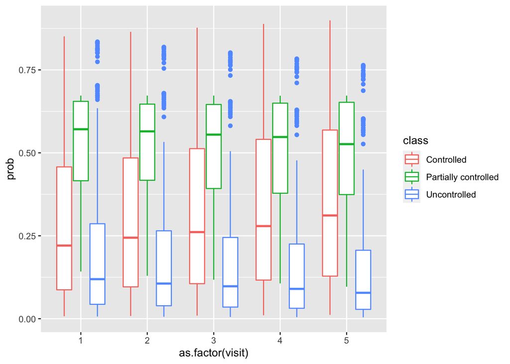

```r
ggplot(data=tmp,aes(x=as.factor(visit),y=prob,colour=class))+
  geom_boxplot()
```

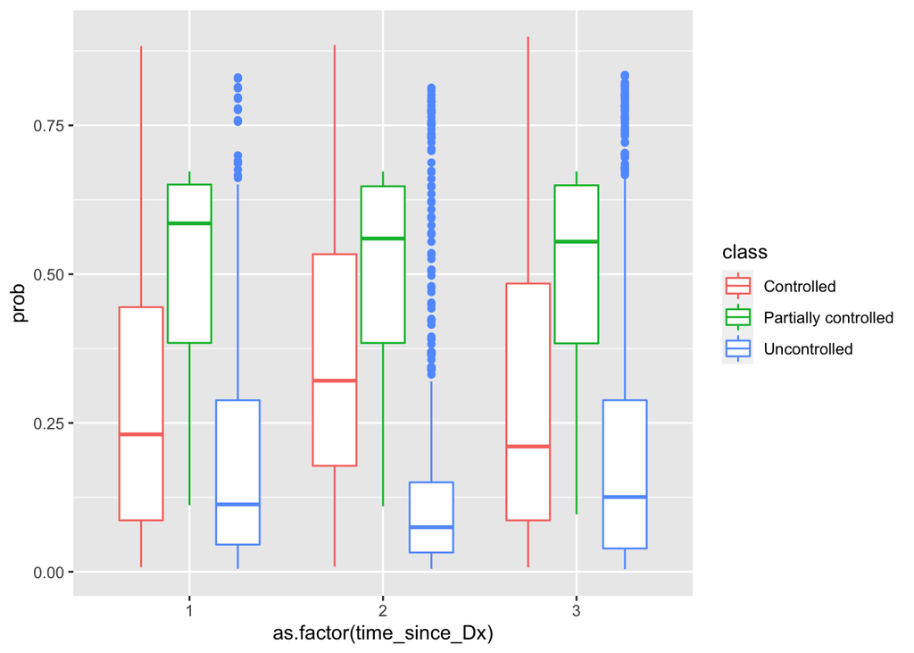

```r
ggplot(data=tmp,aes(x=as.factor(time_since_Dx),y=prob,colour=class))+
  geom_boxplot()
```